# Atlas data occupancy models - example

Author

Florencia Grattarola

Published

November 26, 2024

This code is based on https://doserlab.com/files/spoccupancy-web/articles/spacetimemodelshtml. For a more basic start, check https://doserlab.com/files/spoccupancy-web/articles/modelfitting.

```r
library(janitor)
library(patchwork)
library(sf)
sf_use_s2(FALSE)
library(spOccupancy)
library(tidyverse)
```

## Function to run occ models

The variables’ names in this function are based on our atlas data column name standards.

cell_label cell_grouping effort area

```r
runATLASocc <- function(sp_list,
                        atlas_data, atlas_grid_path, atlas_grid_layer,
                        atlas_cell_grouping, atlas_period, acce_grids) {

  ################################################
  # ATLAS DATA PREPARATION

  atlas_grid <- sf::st_read(atlas_grid_path, layer=atlas_grid_layer, quiet = T)

  grid_coords <- atlas_grid %>%
    select(cell_label, area, X=cell_long, Y=cell_lat)

  grid_effort <- left_join(atlas_grid %>% select(cell_label),
                           atlas_data %>% filter(period == atlas_period &
                                                   cell_grouping == atlas_cell_grouping) %>%
                             distinct(cell_label, effort, area))

  # DATA FOR PREDICTIONS
  X.0 <- matrix(1, nrow(grid_coords), 1)
  coords.0 <- as.matrix(st_drop_geometry(grid_coords)[, c('X', 'Y')]) # some unsampled grids
  V.det.covs <- st_join(acce_grids, grid_effort, left = T, join = st_equals) %>%
    select(cell_label=cell_label.x, acce, effort)

  acce.pred <- (V.det.covs$acce - mean(V.det.covs$acce)) / sd(V.det.covs$acce)
  effort.pred <- (V.det.covs$effort - mean(V.det.covs$effort, na.rm=T)) / sd(V.det.covs$effort, na.rm=T)
  V.0 <- cbind(1, effort.pred, acce.pred)

  ################################################
  # ANALYSIS PER SPECIES

  for(sp in sp_list) {

    ################################################
    # 1) species data preparation

    species_data <- atlas_data %>%
      filter(period == atlas_period & cell_grouping == atlas_cell_grouping) %>%
      select(cell_label, verbatim_name, effort, area) %>%
      mutate(presence=1) %>%
      pivot_wider(names_from = verbatim_name,
                  values_from = presence,
                  values_fill = c(list(presence=0))) %>%
      janitor::clean_names() %>%
      select(presence=all_of(sp), cell_label, effort, area) %>%
      left_join(., acce_grids) %>%
      arrange(cell_label)

    sp_coords <- right_join(atlas_grid %>%
                              select(cell_label, X=cell_long, Y=cell_lat),
                            species_data) %>% st_drop_geometry() %>%
      select(X, Y) %>% as.matrix()

    ################################################
    # 2) data for the model

    y.species <- data.frame(y=species_data$presence)
    det.covs <- data.frame(effort = matrix(species_data$effort),
                           acce = matrix(species_data$acce))
    coords <- data.frame(X = matrix(sp_coords[,1]),
                         Y = matrix(sp_coords[,2]))

    data.species <- list(y = y.species,
                         det.covs = det.covs,
                         coords = coords)

    dist.species <- dist(data.species$coords) # spatial component
    cov.model <- "exponential"

    species.inits <- list(alpha = 0,
                          beta = 0,
                          z = data.species$y,
                          sigma.sq = 2,
                          phi = 3 / mean(dist.species),
                          w = rep(0, nrow(data.species$y)))

    batch.length <- 100
    n.batch <- 1000
    n.burn <- 5000
    n.thin <- 20
    n.chains <- 3

    species.tuning <- list(phi = 1)
    # accept.rate = 0.43 by default, so we do not specify it.

    min.dist <- min(dist.species)
    max.dist <- max(dist.species)
    species.sp.priors <- list(beta.normal = list(mean = 0, var = 2.72),
                              alpha.normal = list(mean = 0, var = 2.72),
                              sigma.sq.ig = c(2, 1),
                              phi.unif = c(3/max.dist, 3/min.dist))

    n.omp.threads <- 1
    verbose <- TRUE
    n.report <- 500 # reports progress at every 100th batch.

    ################################################
    # 3) model fil

    out.species <- spPGOcc(occ.formula = ~ 1,
                           det.formula = ~ scale(effort) + scale(acce),
                           data = data.species,
                           # inits = species.inits,
                           n.batch = n.batch,
                           batch.length = batch.length,
                           priors = species.sp.priors,
                           cov.model = cov.model,
                           NNGP = TRUE,
                           n.neighbors = 5,
                           tuning = species.tuning,
                           n.report = n.report,
                           n.burn = n.burn,
                           n.thin = n.thin,
                           n.chains = n.chains)

    ################################################
    # 4) predictive check

    ppc.species.out <- ppcOcc(out.species, fit.stat = 'freeman-tukey', group = 1)
    summary(ppc.species.out)

    ppc.species.df <- data.frame(fit = ppc.species.out$fit.y,
                                 fit.rep = ppc.species.out$fit.y.rep,
                                 color = 'lightskyblue1')
    ppc.species.df$color[ppc.species.df$fit.rep > ppc.species.df$fit] <- 'lightsalmon'
    plot(ppc.species.df$fit, ppc.species.df$fit.rep, bg = ppc.species.df$color, pch = 21,
         ylab = 'Fit', xlab = 'True')
    lines(ppc.species.df$fit, ppc.species.df$fit, col = 'black')

    ################################################
    # 5) predictions

    # occupancy
    pred.occ <- predict(out.species, X.0, coords.0,
                        verbose = FALSE,
                        type='occupancy')

    # detection
    pred.det <- predict(out.species, V.0, coords.0,
                        verbose = FALSE,
                        type = 'detection')

    ################################################
    # 6) plots

    data.pred <- tibble(x = grid_coords$X,
                         y = grid_coords$Y,
                         mean.psi = apply(pred.occ$psi.0.samples, 2, mean),
                         sd.psi = apply(pred.occ$psi.0.samples, 2, sd),
                         mean.w = apply(pred.occ$w.0.samples, 2, mean),
                         sd.w = apply(pred.occ$w.0.samples, 2, sd),
                         mean.p = apply(pred.det$p.0.samples, 2, mean, na.rm = TRUE),
                         sd.p = apply(pred.det$p.0.samples, 2, sd, na.rm = TRUE))

    data.pred.sf <- st_as_sf(data.pred, coords = c('x', 'y'), crs=4326)

    sp_name <- str_to_sentence(str_replace(sp, '_', ' '))
    raw.occ <- round(sum(species_data$presence) / nrow(species_data),2)
    alpha.det <- round(plogis(mean(out.species$alpha.samples)),3)
    beta.occ <- round(plogis(mean(out.species$beta.samples)),3)
  }
  return(list(data.pred.sf, sp_name, raw.occ, alpha.det, beta.occ))
}
```

## Atlas species data

```r
# crs_atlas <- 'EPSG:4156'
atlas_data <- readRDS('data/Birds_Atlas_Czechia_beast_data.rds') %>%
  mutate(period = case_when(start_year==1985 & end_year==1989 ~ 1,
                            start_year==2001 & end_year==2003 ~ 2,
                            start_year==2014 & end_year==2017 ~ 3)) # adapt to the atlas

atlas_grid_path <- 'data/Birds_Atlas_Czechia_grid.gpkg'

acce_grids <- readRDS('data/acce_grids.rds') %>% rename(acce=acc_50k)
# acce_grids_path <- 'data/acce_grids.gpkg' # to have a layer for each grid cell aggregation
```

## Model fit

Here’s how the function works

```r
runATLASocc(sp_list, atlas_data,
            atlas_grid_path, atlas_grid_layer,
            atlas_cell_grouping, atlas_period,
            acce_grids)
```

**Parameters**:

- `sp_list` = a list of species to be analysed,
- `atlas_data` = the entire dataset for the atlas,
- `atlas_cell_grouping` = the cell grouping value in the data (corresponds to the atlas resolution) , e.g., `atlas_cell_grouping = 1` corresponds to the highest resolution,
- `atlas_grid_path` = the location where the atlas grid information is stored,
- `atlas_grid_layer` = the resolution of the atlas grid we want to consider, e.g., `'cell1grid'` is the highest resolution,
- `atlas_period` = the atlas period we want to analyse, e.g., `1` goes from 1985 to 1989,
- `acce_grids` = the layer of accessibility values per grid cell.

## Example with *Anas strepera*

```
----------------------------------------
    Preparing to run the model
----------------------------------------
----------------------------------------
    Building the neighbor list
----------------------------------------
----------------------------------------
Building the neighbors of neighbors list
----------------------------------------
----------------------------------------
    Model description
----------------------------------------
NNGP Occupancy model with Polya-Gamma latent
variable fit with 628 sites.

Samples per chain: 100000 (1000 batches of length 100)
Burn-in: 5000
Thinning Rate: 20
Number of Chains: 3
Total Posterior Samples: 14250

Using the exponential spatial correlation model.

Using 5 nearest neighbors.

Source not compiled with OpenMP support.

Adaptive Metropolis with target acceptance rate: 43.0
----------------------------------------
    Chain 1
----------------------------------------
Sampling ...
Batch: 500 of 1000, 50.00%
    Parameter   Acceptance  Tuning
    phi     69.0        0.22091
-------------------------------------------------
Batch: 1000 of 1000, 100.00%
----------------------------------------
    Chain 2
----------------------------------------
```

[output cut: 12 more lines]

```
    phi     52.0        0.22091
-------------------------------------------------
Batch: 1000 of 1000, 100.00%

Call:
ppcOcc(object = out.species, fit.stat = "freeman-tukey", group = 1)

Samples per Chain: 100000
Burn-in: 5000
Thinning Rate: 20
Number of Chains: 3
Total Posterior Samples: 14250

Bayesian p-value:  0.4931
Fit statistic:  freeman-tukey
```

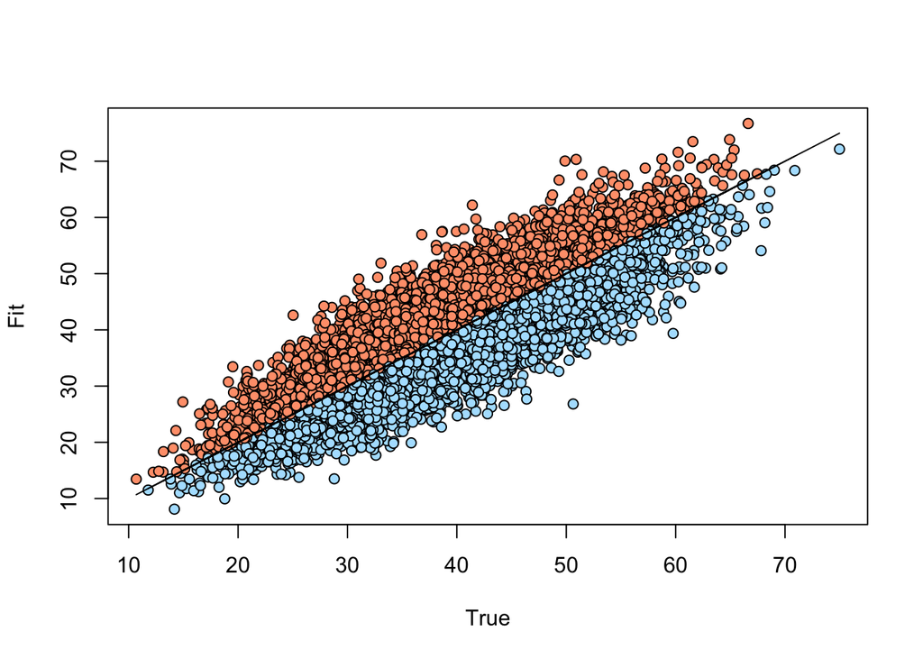

```r
atlas_grid_layer <- 'cell1grid'
atlas_cell_grouping <- 1 # for now, the only possibility (constrained by acce)
sp_list <- c('anas_strepera')

atlas_occ_period_1 <- runATLASocc(sp_list, atlas_data,
                                  atlas_grid_path, atlas_grid_layer,
                                  atlas_cell_grouping, atlas_period=1,
                                  acce_grids)
```

```
----------------------------------------
    Preparing to run the model
----------------------------------------
----------------------------------------
    Building the neighbor list
----------------------------------------
----------------------------------------
Building the neighbors of neighbors list
----------------------------------------
----------------------------------------
    Model description
----------------------------------------
NNGP Occupancy model with Polya-Gamma latent
variable fit with 628 sites.

Samples per chain: 100000 (1000 batches of length 100)
Burn-in: 5000
Thinning Rate: 20
Number of Chains: 3
Total Posterior Samples: 14250

Using the exponential spatial correlation model.

Using 5 nearest neighbors.

Source not compiled with OpenMP support.

Adaptive Metropolis with target acceptance rate: 43.0
----------------------------------------
    Chain 1
----------------------------------------
Sampling ...
Batch: 500 of 1000, 50.00%
    Parameter   Acceptance  Tuning
    phi     29.0        0.20805
-------------------------------------------------
Batch: 1000 of 1000, 100.00%
----------------------------------------
    Chain 2
----------------------------------------
```

[output cut: 12 more lines]

```
    phi     42.0        0.22537
-------------------------------------------------
Batch: 1000 of 1000, 100.00%

Call:
ppcOcc(object = out.species, fit.stat = "freeman-tukey", group = 1)

Samples per Chain: 100000
Burn-in: 5000
Thinning Rate: 20
Number of Chains: 3
Total Posterior Samples: 14250

Bayesian p-value:  0.53
Fit statistic:  freeman-tukey
```

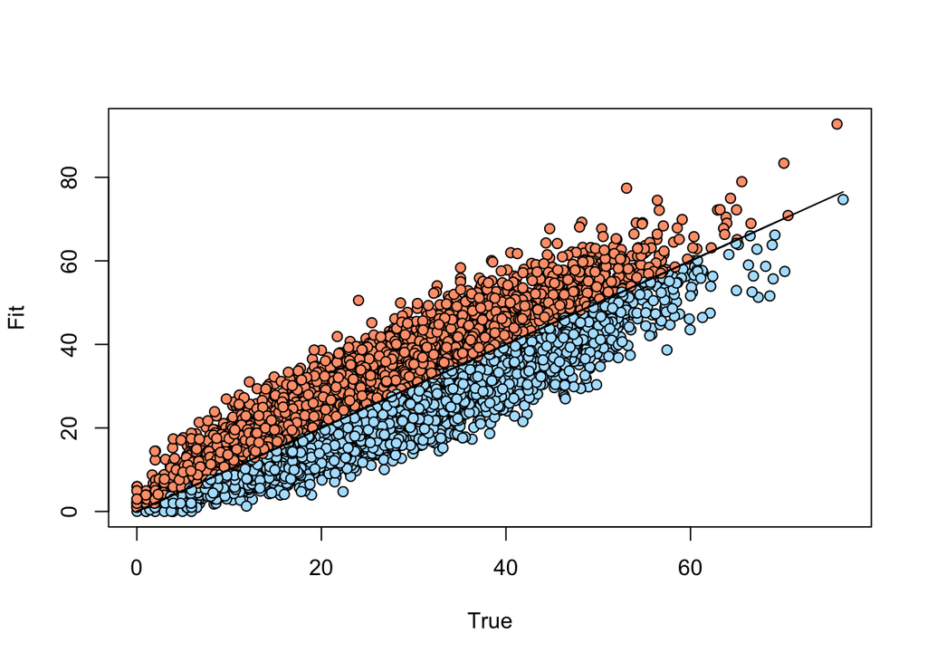

```r
atlas_occ_period_2 <- runATLASocc(sp_list, atlas_data,
                                  atlas_grid_path, atlas_grid_layer,
                                  atlas_cell_grouping, atlas_period=2,
                                  acce_grids)
```

```
----------------------------------------
    Preparing to run the model
----------------------------------------
----------------------------------------
    Building the neighbor list
----------------------------------------
----------------------------------------
Building the neighbors of neighbors list
----------------------------------------
----------------------------------------
    Model description
----------------------------------------
NNGP Occupancy model with Polya-Gamma latent
variable fit with 671 sites.

Samples per chain: 100000 (1000 batches of length 100)
Burn-in: 5000
Thinning Rate: 20
Number of Chains: 3
Total Posterior Samples: 14250

Using the exponential spatial correlation model.

Using 5 nearest neighbors.

Source not compiled with OpenMP support.

Adaptive Metropolis with target acceptance rate: 43.0
----------------------------------------
    Chain 1
----------------------------------------
Sampling ...
Batch: 500 of 1000, 50.00%
    Parameter   Acceptance  Tuning
    phi     52.0        0.20805
-------------------------------------------------
Batch: 1000 of 1000, 100.00%
----------------------------------------
    Chain 2
----------------------------------------
```

[output cut: 12 more lines]

```
    phi     49.0        0.20805
-------------------------------------------------
Batch: 1000 of 1000, 100.00%

Call:
ppcOcc(object = out.species, fit.stat = "freeman-tukey", group = 1)

Samples per Chain: 100000
Burn-in: 5000
Thinning Rate: 20
Number of Chains: 3
Total Posterior Samples: 14250

Bayesian p-value:  0.5874
Fit statistic:  freeman-tukey
```

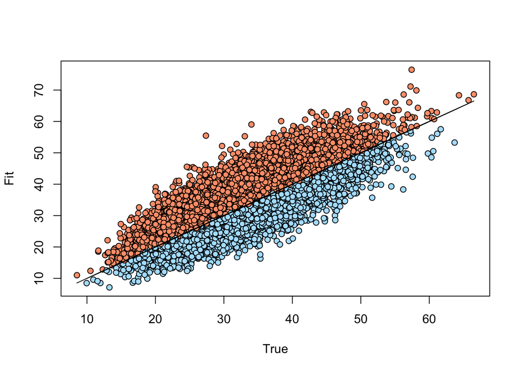

```r
atlas_occ_period_3 <- runATLASocc(sp_list, atlas_data,
                                  atlas_grid_path, atlas_grid_layer,
                                  atlas_cell_grouping, atlas_period=3,
                                  acce_grids)
```

### Plots

Presence/absence data, detection variables (effort and accessibility), occupancy and detection probabilities for the example species at the first atlas period (1985-1989).

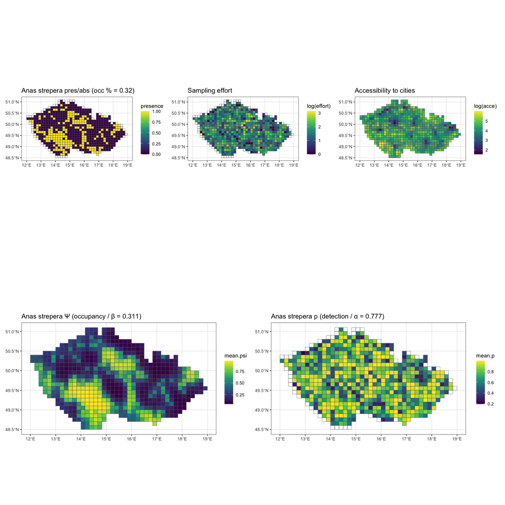

```r
atlas_period <- 1
data.pred <- atlas_occ_period_1[[1]] # data.pred.sf
sp_name <- atlas_occ_period_1[[2]]
sp <- str_to_lower(str_replace(sp_name, ' ', '_'))
raw.occ <- atlas_occ_period_1[[3]]
alpha.det <- atlas_occ_period_1[[4]]
beta.occ <- atlas_occ_period_1[[5]]

atlas_grid <- sf::st_read(atlas_grid_path, layer=atlas_grid_layer, quiet = T)
predictions_example_species <- st_join(atlas_grid, data.pred)

plot_psi <- ggplot() +
  geom_sf(data = predictions_example_species, aes(fill = mean.psi)) +
  scale_fill_viridis_c(na.value = 'transparent') +
  labs(title= str_glue('{sp_name} \u03A8 (occupancy / \u03B2 = {beta.occ})')) +
  theme_bw()

plot_p <- ggplot() +
  geom_sf(data = predictions_example_species, aes(fill = mean.p)) +
  scale_fill_viridis_c(na.value = 'transparent') +
  labs(title= str_glue('{sp_name} p (detection / \u03B1 = {alpha.det})' )) +
  theme_bw()

example_grid_effort <- left_join(atlas_grid %>% select(cell_label),
                                 atlas_data %>% filter(period == atlas_period &
                                                         cell_grouping == atlas_cell_grouping) %>%
                                   distinct(cell_label, effort, area))

example_species_data <- atlas_data %>%
  filter(period == atlas_period & cell_grouping == atlas_cell_grouping) %>%
  select(cell_label, verbatim_name, effort, area) %>%
  mutate(presence=1) %>%
  pivot_wider(names_from = verbatim_name,
              values_from = presence,
              values_fill = c(list(presence=0))) %>%
  janitor::clean_names() %>%
  select(presence=all_of(sp), cell_label, effort, area) %>%
  left_join(., acce_grids) %>%
  arrange(cell_label)

effort_example_species <- left_join(example_grid_effort, example_species_data)

plot_y <- ggplot() +
  geom_sf(data = effort_example_species,
          aes(fill = presence)) +
  scale_fill_viridis_c(na.value = 'transparent') +
  labs(title= str_glue('{sp_name} pres/abs (occ % = {raw.occ})' )) +
  theme_bw()

plot_effort <- ggplot() +
  geom_sf(data = example_grid_effort, aes(fill = log(effort))) +
  scale_fill_viridis_c(na.value = 'transparent') +
  labs(title= 'Sampling effort') +
  theme_bw()

plot_acce <- ggplot() +
  geom_sf(data = acce_grids, aes(fill = log(acce))) +
  scale_fill_viridis_c(na.value = 'transparent') +
  labs(title= 'Accessibility to cities') +
  theme_bw()

(plot_y | plot_effort | plot_acce)/ (plot_psi | plot_p)
```

Presence/absence data and occupancy probabily for the example species at each of the atlases periods.

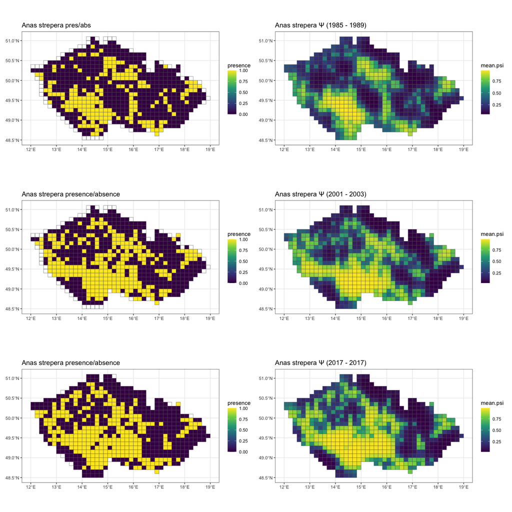

```r
data.pred.1 <- atlas_occ_period_1[[1]] # data.pred.sf
data.pred.2 <- atlas_occ_period_2[[1]] # data.pred.sf
data.pred.3 <- atlas_occ_period_3[[1]] # data.pred.sf
atlas_grid <- sf::st_read(atlas_grid_path, layer=atlas_grid_layer, quiet = T)

predictions_example_species_1 <- st_join(atlas_grid, data.pred.1)
predictions_example_species_2 <- st_join(atlas_grid, data.pred.2)
predictions_example_species_3 <- st_join(atlas_grid, data.pred.3)

example_species_data_1 <- atlas_data %>%
  filter(period == 1 & cell_grouping == atlas_cell_grouping) %>%
  select(cell_label, verbatim_name, effort, area) %>%
  mutate(presence=1) %>%
  pivot_wider(names_from = verbatim_name,
              values_from = presence,
              values_fill = c(list(presence=0))) %>%
  janitor::clean_names() %>%
  select(presence=all_of(sp), cell_label, effort, area) %>%
  left_join(., acce_grids) %>%
  arrange(cell_label)

example_species_data_2 <- atlas_data %>%
  filter(period == 2 & cell_grouping == atlas_cell_grouping) %>%
  select(cell_label, verbatim_name, effort, area) %>%
  mutate(presence=1) %>%
  pivot_wider(names_from = verbatim_name,
              values_from = presence,
              values_fill = c(list(presence=0))) %>%
  janitor::clean_names() %>%
  select(presence=all_of(sp), cell_label, effort, area) %>%
  left_join(., acce_grids) %>%
  arrange(cell_label)

example_species_data_3 <- atlas_data %>%
  filter(period == 3 & cell_grouping == atlas_cell_grouping) %>%
  select(cell_label, verbatim_name, effort, area) %>%
  mutate(presence=1) %>%
  pivot_wider(names_from = verbatim_name,
              values_from = presence,
              values_fill = c(list(presence=0))) %>%
  janitor::clean_names() %>%
  select(presence=all_of(sp), cell_label, effort, area) %>%
  left_join(., acce_grids) %>%
  arrange(cell_label)


plot_psi_1 <- ggplot() +
  geom_sf(data = predictions_example_species_1, aes(fill = mean.psi)) +
  scale_fill_viridis_c(na.value = 'transparent') +
  labs(title= str_glue('{sp_name} \u03A8 (1985 - 1989)')) +
  theme_bw()

plot_y_1 <- ggplot() +
  geom_sf(data = left_join(atlas_grid, example_species_data_1),
          aes(fill = presence)) +
  scale_fill_viridis_c(na.value = 'transparent') +
  labs(title= str_glue('{sp_name} pres/abs' )) +
  theme_bw()

plot_psi_2 <- ggplot() +
  geom_sf(data = predictions_example_species_2, aes(fill = mean.psi)) +
  scale_fill_viridis_c(na.value = 'transparent') +
  labs(title= str_glue('{sp_name} \u03A8 (2001 - 2003)')) +
  theme_bw()

plot_y_2 <- ggplot() +
  geom_sf(data = left_join(atlas_grid, example_species_data_2),
          aes(fill = presence)) +
  scale_fill_viridis_c(na.value = 'transparent') +
  labs(title= str_glue('{sp_name} presence/absence' )) +
  theme_bw()

plot_psi_3 <- ggplot() +
  geom_sf(data = predictions_example_species_3, aes(fill = mean.psi)) +
  scale_fill_viridis_c(na.value = 'transparent') +
  labs(title= str_glue('{sp_name} \u03A8 (2017 - 2017)')) +
  theme_bw()

plot_y_3 <- ggplot() +
  geom_sf(data = left_join(atlas_grid, example_species_data_3),
          aes(fill = presence)) +
  scale_fill_viridis_c(na.value = 'transparent') +
  labs(title= str_glue('{sp_name} presence/absence' )) +
  theme_bw()


(plot_y_1 | plot_psi_1)/ (plot_y_2 | plot_psi_2) / (plot_y_3 | plot_psi_3)
```

## Species list

```r
sp_list <- c('anas_strepera', 'ciconia_ciconia',
             'tyto_alba', 'haliaeetus_albicilla',
             'upupa_epops', 'merops_apiaster',
             'jynx_torquilla', 'dendrocopos_minor',
             'larus_ridibundus', 'charadrius_dubius',
             'tetrastes_bonasia', 'streptopelia_turtur',
             'pyrrhula_pyrrhula', 'oriolus_oriolus',
             'luscinia_megarhynchos')

sp_list <- c('anas_strepera', 'ciconia_ciconia')
```